# Predicting type of activity from movement data

MJ

April 26, 2017

#### Note

The rmarkdown and html file for this project are at https://github.com/datamj2/pml_wk04_proj

## Introduction

I used a publicly available human activity dataset to predict five types of exercise activity. Data was collected from six participants who wore accelerometers strapped to their persons (belt, forearm, arm) and to a dumbell. The subjects performed barbell lifts five ways: both incorrectly and correctly. The accelerometer data was then used to train a machine learning algorithm and assess its performance on a hold-out data set.

## Exploratory analysis

The original training and test sets are described at http://groupware.les.inf.puc-rio.br/har (see WLE Dataset). The structure of the first 10 columns is shown below.

```
'data.frame':   19622 obs. of  10 variables:
 $ X                   : int  1 2 3 4 5 6 7 8 9 10 ...
 $ user_name           : Factor w/ 6 levels "adelmo","carlitos",..: 2 2 2 2 2 2 2 2 2 2 ...
 $ raw_timestamp_part_1: int  1323084231 1323084231 1323084231 1323084232 1323084232 1323084232 1323084232 1323084232 1323084232 1323084232 ...
 $ raw_timestamp_part_2: int  788290 808298 820366 120339 196328 304277 368296 440390 484323 484434 ...
 $ cvtd_timestamp      : Factor w/ 20 levels "02/12/2011 13:32",..: 9 9 9 9 9 9 9 9 9 9 ...
 $ new_window          : Factor w/ 2 levels "no","yes": 1 1 1 1 1 1 1 1 1 1 ...
 $ num_window          : int  11 11 11 12 12 12 12 12 12 12 ...
 $ roll_belt           : num  1.41 1.41 1.42 1.48 1.48 1.45 1.42 1.42 1.43 1.45 ...
 $ pitch_belt          : num  8.07 8.07 8.07 8.05 8.07 8.06 8.09 8.13 8.16 8.17 ...
 $ yaw_belt            : num  -94.4 -94.4 -94.4 -94.4 -94.4 -94.4 -94.4 -94.4 -94.4 -94.4 ...
```

```
Original training set dimensions, rows x cols: 19622 x 160
```

There are 160 features (columns) in the data set. The first seven columns consist of an index column, subject name, three timestamp columns, a new_window and a num_window column. The outcome variable is ‘classe’, which is a factor variable coding the 5 activity types (A-E). There appear to be a large number of columns that contain mostly NA values. The remaining columns appear to contain the accelerometer data. The new_window column contains two entries: “no” and “yes”. The “yes” rows contain aggregated accelerometer data and the raw accelerometer data. The num_window columns contain a number identifying the time window. The aggregated data appear to occur only in the NA columns, and seem to be the only non-NA entries in these columns, at least for most of the rows. Some of the NA-columns are also coded as factors, while others are integer or numeric. The rest of the acceleromter data columns are coded as numeric or integer values, collected. over a time window.

Figure 1 is a plot of the proportion of NA values for each column. The columns have either 0% NA values or 97.9% NA values, with about 1.7 times as many of the latter compared to the former.

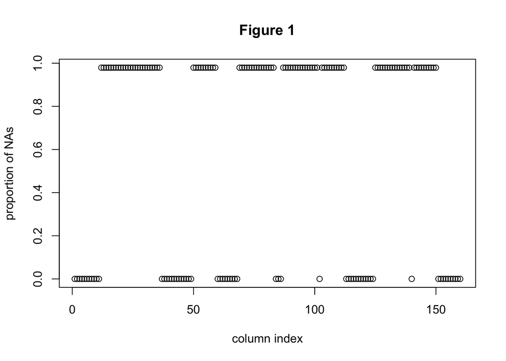

Figure 1. Proportion of NAs for each predictor. There are two levels: columns with no NAs (n=60), or columns with 0.979 NAs (n=100)

## Machine learning considerations

I will use the random forest method to train the predictive model because of its high accuracy (as noted in the lecture). The random forest uses bagging, which improves accuracy and reduces variance, but reduces interpretability (ref: *Introduction to Statistical Learning (6th printing)*, by Gareth James, Daniela Witten, Trevor Hastie and Robert Tibshirani, Springer Science+Business Media, NY). At each split (node) of the tree, a different random subset of predictors is used, rather than splitting each node using the full set of predictors. This reduces correlations amongst the bagged trees, due for example, to the presence of a few strong predictors. Thus, using a random subset of predictors (where the size of the subset does not change) reduces variability and increases the reliability of the model.

### Cross-validation method

The caret package in R uses a bootstrap method (by default) to partition the data (n=25). This can be time-consuming for this data set when using a personal computer. Another method to partition the data is k-fold cross validation (cv, see https://github.com/lgreski/datasciencectacontent/blob/master/markdown/pml-randomForestPerformance.md). It has been noted that k=5 reduces computational time without greatly reducing accuracy. With this partitioning method the data set is partitioned 5 times, and the model trained on the resulting partitions.

### Out-of-bag error

Because of the way the caret package builds the random forest model (using either the bootstrap or the cv method), a separate cross-validation step is not necessary. In effect, cross-validation occurs during model building. For each partition of the training set, that is, for each bag, there is also a validation set, which contain the out-of-bag (OOB) observations. The observations in the validation sets can be used to estimate the error on a test set (ie hold-out set), that is, a set that was not used to train the model. This is known as OOB error, and is a good predictor of error in a hold-out set.

If the random forest method does not generate high enough accuracy (>99%, see https://github.com/lgreski/datasciencectacontent/blob/master/markdown/pml-requiredModelAccuracy.md), then a second model will be built using the generalized boosted regression model (gbm) in caret. This high accuracy is necessary because the probabililty of correctly predicting 20 cases with 99% accuracy is 0.99^20 = 0.82, while the probability of correctly predicting 20 cases with, say, 90% accuracy is 0.90^20 = 0.12.

## Split into training and test/hold-out sets

The original training data set seems large enough (nrow=19622) to use a 60-20-20 split resulting in: a new training set, a validation set, and a new test or hold-out set. However, because I’m using the random forest method in the caret package - using cross-validation resampling to train the model and obtain an OOB error (see above) - I will partition the original training data using an 80-20 split: a new training set, and a hold-out set. Note that if the OOB error is used, this partitioning is not necessary, but I will use a hold-out set (20% split) as a second check on the generalizability of the model.

```r
library(caret)
set.seed(8876)
ind<-createDataPartition(tr$classe,p=0.80,list=F)
tr2<-tr[ind,]
ts2<-tr[-ind,]
```

```
New training set dimensions after partition (rows x cols): 15699 x 160
```

```
hold out set dimensions after partition (rows x cols): 3923 x 160
```

## Feature selection

Columns with high numbers of NA will add to the computational demands of training the machine language algorithm, but may not appreciably increase the predictive accuracy. For that reason, the columns containing large proportions of NAs will be removed from the training set. The first six columns from training set will also be removed, because they are not expected to add much to the final model accuracy (the seventh column, num_window, may be useful). Therefore, the machine language algorithm will be trained using mainly the windowed accelerometer data.

```r
tr2<-tr2[colSums(!is.na(tr)) > nrow(tr) * 0.5]
tr2<-tr2[,-c(1:6)]
```

```
Training set dimensions after feature selection (rows x cols): 15699 x 54
```

Note that only the new training set will be reduced in (column) size: removing columns from the hold-out set is not necessary.

## Results

### Random forest model

```r
# the following parallel and trainControl is taken from https://github.com/lgreski/datasciencectacontent/blob/master/markdown/pml-randomForestPerformance.md
fitControl <- trainControl(method = "cv",
                           number = 5,
                           allowParallel = TRUE)
library(parallel)
library(doParallel)
cluster <- makeCluster(detectCores() - 1) # convention to leave 1 core for OS
registerDoParallel(cluster)

set.seed(1452)
mr2<-train(classe ~ .,data=tr2,method="rf",trControl=fitControl,prox=T)

stopCluster(cluster)
registerDoSEQ()
```

```
Random Forest

15699 samples
   53 predictor
    5 classes: 'A', 'B', 'C', 'D', 'E'

No pre-processing
Resampling: Cross-Validated (5 fold)
Summary of sample sizes: 12558, 12559, 12560, 12561, 12558
Resampling results across tuning parameters:

  mtry  Accuracy   Kappa
   2    0.9944581  0.9929895
  27    0.9974520  0.9967770
  53    0.9959232  0.9948430

Accuracy was used to select the optimal model using  the largest value.
The final value used for the model was mtry = 27.
```

The information above confirms that a 5-fold cross-validation resampling method was used, and that the highest accuracy was obtained with a random subset of 27 predictors (mtry=27) used at each node. (See Rstudio help documentation (?train, ?randomForest, http://topepo.github.io/caret/train-models-by-tag.html#Random_Forest for mtry defintion).

### In and out of sample error

In sample error is the error for the predictions on the new training set (not the original training set). Out of sample error is the prediction error on the hold-out set.

```r
pr2<-predict(mr2,tr2)
ind<-pr2==tr2$classe
ind2<-pr2!=tr2$classe
insample_err<-100*(sum(ind2)/length(tr2$class)) # in sample error
insample_acc<-100*(sum(ind)/length(tr2$class)) # in sample accuracy
```

```
In sample error(%) 0.0000 (accuracy: 100.0000)
```

```r
ps2<-predict(mr2,ts2)
ind<-ps2==ts2$classe
ind2<-ps2!=ts2$classe
outsample_err<-100*(sum(ind2)/length(ts2$class)) # out of  sample error
outsample_acc<-100*(sum(ind)/length(ts2$class)) # out of sample accuracy
```

```
Out of sample error(%)  0.1529 (accuracy: 99.8471)
```

As expected, the out of sample error is higher than the in sample error.

### OOB error

The oob error is listed in the final model, and can be calculated from the confusion matrix (sum of diagonal/sum of entire confusion matrix). It is reprinted to 4 decimal places below. The OOB error differs from the in-sample error (see above) because the in-sample error is calculated from the model predictions on the entire new training set, while the OOB error is calculated on the out-of-bag observations using only those trees where the oob observations were excluded.

```r
mr2$finalModel
```

```
Call:
 randomForest(x = x, y = y, mtry = param$mtry, proximity = ..1)
               Type of random forest: classification
                     Number of trees: 500
No. of variables tried at each split: 27

        OOB estimate of  error rate: 0.18%
Confusion matrix:
     A    B    C    D    E  class.error
A 4462    1    0    0    1 0.0004480287
B    7 3029    2    0    0 0.0029624753
C    0    6 2732    0    0 0.0021913806
D    0    0    7 2565    1 0.0031092110
E    0    0    0    4 2882 0.0013860014
```

```
OOB error(%)  0.1847 (accuracy: 99.8153)
```

The out-of-bag error agrees quite closely with the out-of-sample error. Because both error estimates are so low, or in other words, because the prediction accuracy is so high (>99%), there is no need to train a second model using a different method.

### Variable importance

Table 1 lists the ten most important variables (predictors) and ten least important variables (based on the Gini index).

```r
vi<-varImp(mr2)
```

Table 1. List of 10 most and least important predictors, in descending order of importance.

| 10 most important | Overall |  | 10 least important | Overall |
| --- | --- | --- | --- | --- |
| num_window | 100.00 |  | gyros_belt_x | 0.99 |
| roll_belt | 60.63 |  | gyros_forearm_y | 0.98 |
| pitch_forearm | 37.38 |  | total_accel_forearm | 0.88 |
| yaw_belt | 32.86 |  | accel_arm_z | 0.87 |
| magnet_dumbbell_z | 28.04 |  | gyros_arm_x | 0.82 |
| pitch_belt | 26.34 |  | total_accel_arm | 0.81 |
| magnet_dumbbell_y | 26.07 |  | gyros_dumbbell_z | 0.37 |
| roll_forearm | 19.09 |  | gyros_forearm_z | 0.35 |
| accel_dumbbell_y | 11.66 |  | gyros_forearm_x | 0.14 |
| magnet_dumbbell_x | 11.12 |  | gyros_arm_z | 0.00 |

### Class centers

Figure 2 plots the class centers for plots of the two most important variables and two least important variables from Table 1. Although there is no clear clustering of the individual data points in either of the top panels, the class centers are better separated for the two most important variables compared to the two least important variables (see bottom panels).

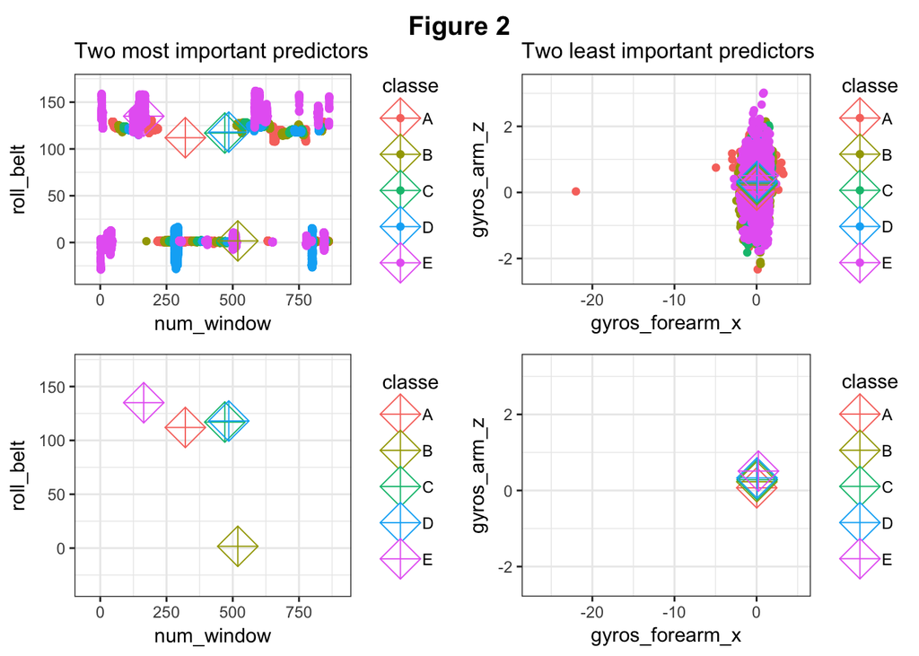

Figure 2. The two most important predictors are plotted by class (ie classe) in the first column. The class centers appear in both panels; individual observations appear only in the top panel. The two least important predictors are plotted in the right column.